# MPEA Power Analysis

Ali Shojaee Bakhtiari

2019-February-19

# Running the power Scripts

In this step we run and save the Power analysis for each of the 4 scenarios i.e. : 1) Keeping the effect constant and changing Enrichment levels 2) Keeping enrichment level constant and varying effect level. 3) Changing the pathway size compensation window Sizes 4) Changing the pathway sizes. The default values ( unless changed for the process): 1) 1% background enrichment and 10% pathway enrichment 2) Expression size = 10000 3) Pathway size= 100 4) Background effect=1, Pathway effect=10 ( Ratio 10:1) 5) Pathway reduction compensator size=10

```r
# source(file = "power_analysis_similar_effect_variable_enrichment.R")
# source(file = "power_analysis_variable_effect_similar_enrichment.R")
# source(file = "power_analysis_window_size.R")
# source(file = "power_analysis_variable_pathway_size.R")
```

# Uploading Packages

```r
require(reshape2)
```

```r
require(ggplot2)
```

# Power Analysis of changing Enrichment percentage inside the pathway while keeping the effect sizes equal

In this Scenario we focus on the effect of changing the enrichment level alone while the effect is similar for pathway and background. When Pathway enrichment = 0.01 t is indistinguishable from the background and power increases as the enrichment level increases.

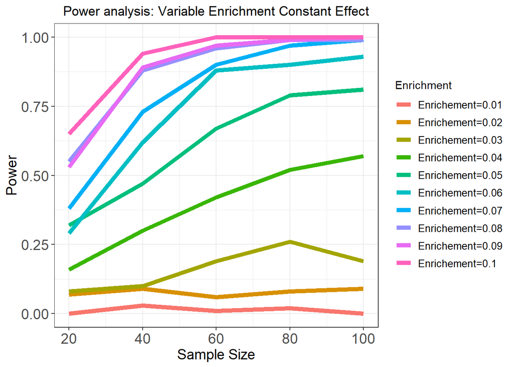

```r
p_value_similar_effect_variable_enrichment <- readRDS(file = "p_value_similar_effect_variable_enrichment_mean.RDS")
enrichment_percentage_pathway= seq(0.01,.1, by=0.01)
power_output <- list()
nsamples <- seq(20,100,20)
for (jj in 1:length(enrichment_percentage_pathway)){
 aux <- sapply(p_value_similar_effect_variable_enrichment, FUN = function(x) x[[jj]]< 0.05  )
 power_output[[jj]] <- rowSums(aux)/dim(aux)[2]

}
names(power_output) <- paste( "Enrichement=",enrichment_percentage_pathway, sep = "")
power_analysis <- melt(power_output)
power_analysis$Sample_size <- nsamples
names(power_analysis) <- c("Power", "Enrichment","Sample_size")
p <- ggplot(data = power_analysis, aes(x = Sample_size, y = Power, color=Enrichment))+ geom_line(size=2)+theme_bw()+
  theme(axis.text=element_text(size=14), axis.title=element_text(size=14), legend.text=element_text(size=10), plot.title = element_text(hjust = 0.5))+xlab("Sample Size")+
  ggtitle("Power analysis: Variable Enrichment Constant Effect")
p
```

# GSEA power analysis variable enrichment constant effect

This result looks weird. I should check and see what may have gone wrong.

```r
# rm(list=ls())
nsamples <- seq(20,100,20)
power_output <- readRDS("GSEA_power_variable_enrichment_similar_effect.RDS")
power_analysis <- melt(power_output)
```

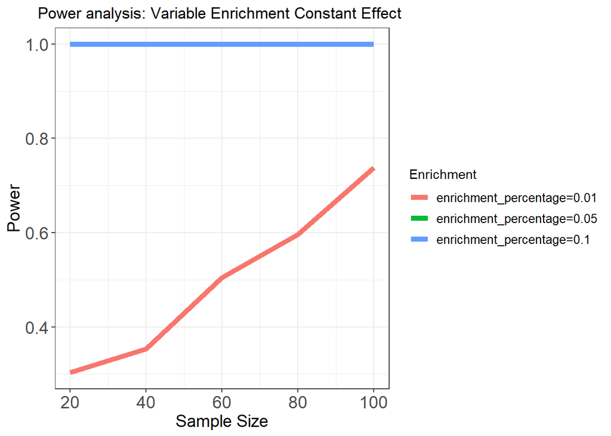

```r
power_analysis$Sample_size <- nsamples
names(power_analysis) <- c("Enrichment","Power","Sample_size")

p <- ggplot(data = power_analysis, aes(x = Sample_size, y = Power, color=Enrichment))+ geom_line(size=2)+theme_bw()+
  theme(axis.text=element_text(size=14), axis.title=element_text(size=14), legend.text=element_text(size=10), plot.title = element_text(hjust = 0.5))+xlab("Sample Size")+
  ggtitle("Power analysis: Variable Enrichment Constant Effect ")
p
```

# Power Analysis of changing Effect size inside the pathway while keeping the enrichment level constant

In this Scenario we focus on the effect of changin the effect size on MPEA and GSEA power. To this aim we keep the enrichment percentage level constant between the pathway and the background and only change the effect size. Effect size= 1 is indistinguishable from the background.

```r
# rm(list=ls())
# p_value_variable_effect_similar_enrichment <- readRDS(file = "p_value_variable_effect_similar_enrichment_mean.RDS")
# effect_size= seq(1,6, by=1)
# # effect_size= c(1,3,6)
#
# power_output <- list()
# nsamples <- seq(20,100,20)
# for (jj in 1:length(effect_size)){
#   aux <- sapply(p_value_variable_effect_similar_enrichment, FUN = function(x) x[[jj]]< 0.05  )
#   power_output[[jj]] <- rowSums(aux)/dim(aux)[2]
#
# }
# names(power_output) <- paste( "Effect=",effect_size, sep = "")
# power_analysis_MPEA <- melt(power_output)
# power_analysis_MPEA$Sample_size <- nsamples
# names(power_analysis_MPEA) <- c("Power", "Effect","Sample_size")
# power_analysis_MPEA$Effect <- paste("MPEA &", power_analysis_MPEA$Effect,sep = "")
#
# # p <- ggplot(data = power_analysis_MPEA, aes(x = Sample_size, y = Power, color=Effect))+ geom_line(size=2)+theme_bw()+
# #   theme(axis.text=element_text(size=14), axis.title=element_text(size=14), legend.text=element_text(size=10), plot.title = element_text(hjust = 0.5))+xlab("Sample Size")+
# #   ggtitle("Power analysis: Variable Effect Size ")
# # p
#
# # rm(list=ls())
# nsamples <- seq(20,100,20)
# power_output_GSEA <- readRDS("GSEA_power_similar_enrichment_variable_effect.RDS")
# power_analysis_GSEA <- melt(power_output_GSEA)
# power_analysis_GSEA$Sample_size <- nsamples
# names(power_analysis_GSEA) <- c("Effect","Power","Sample_size")
# power_analysis_GSEA$Effect <- paste("GSEA &", power_analysis_GSEA$Effect,sep = "")
# power_analysis_GSEA <- power_analysis_GSEA[c("Power", "Effect","Sample_size")]
#
#
# power_analysis <- rbind(power_analysis_MPEA,power_analysis_GSEA)
#
#
# # p <-  ggplot(data = power_analysis_GSEA, aes(x = Sample_size, y = Power, color=Effect))+ geom_line(size=2)+theme_bw()+
# #   theme(axis.text=element_text(size=14), axis.title=element_text(size=14), legend.text=element_text(size=10), plot.title = element_text(hjust = 0.5))+xlab("Sample Size")+
# #   ggtitle("Power analysis: Variable Effect Size ")
# # p
#
# p <-  ggplot(data = power_analysis, aes(x = Sample_size, y = Power, color=Effect))+ geom_line(size=2)+theme_bw()+
#   theme(axis.text=element_text(size=14), axis.title=element_text(size=14), legend.text=element_text(size=10), plot.title = element_text(hjust = 0.5))+xlab("Sample Size")+
#   ggtitle("Power analysis: Variable Effect Size ")
# p
```

# Comparing the power of MPEA against GSEA for different effect and sample sizes

In this set of simulation runs we compared the power of MPEA against GSEA while changing the effect size of the phenotype over the pathway. In our simulation runs for different sample sizes MPEA showed signifcantly higher sensitivity.

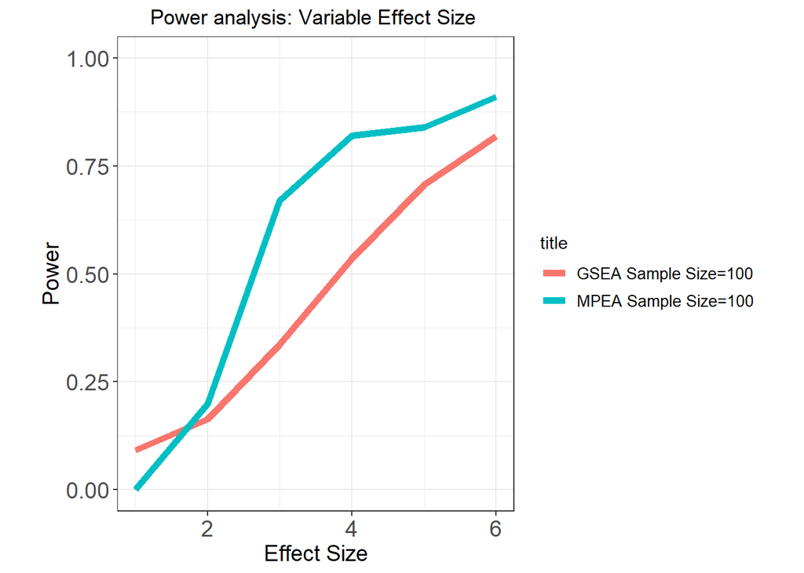

```r
rm(list=ls())
p_value_variable_effect_similar_enrichment <- readRDS(file = "p_value_variable_effect_similar_enrichment_mean.RDS")
effect_size= seq(1,6, by=1)
# effect_size= c(1,3,6)

power_output <- list()
nsamples <- seq(20,100,20)
for (jj in 1:length(effect_size)){
  aux <- sapply(p_value_variable_effect_similar_enrichment, FUN = function(x) x[[jj]]< 0.05  )
  power_output[[jj]] <- rowSums(aux)/dim(aux)[2]

}
names(power_output) <- paste( "Effect=",effect_size, sep = "")
power_analysis_MPEA <- melt(power_output)
power_analysis_MPEA$Sample_size <- (nsamples)
names(power_analysis_MPEA) <- c("Power", "Effect","Sample_size")
power_analysis_MPEA$Effect <- paste("MPEA &", power_analysis_MPEA$Effect,sep = "")
power_analysis_MPEA$Effectvalues= rep(effect_size,each=length(nsamples))
power_analysis_MPEA$title=paste("MPEA Sample Size=",power_analysis_MPEA$Sample_size,sep = "")
# p <- ggplot(data = power_analysis_MPEA, aes(x = Sample_size, y = Power, color=Effect))+ geom_line(size=2)+theme_bw()+
#   theme(axis.text=element_text(size=14), axis.title=element_text(size=14), legend.text=element_text(size=10), plot.title = element_text(hjust = 0.5))+xlab("Sample Size")+
#   ggtitle("Power analysis: Variable Effect Size ")
# p

# rm(list=ls())
nsamples <- seq(20,100,20)
power_output_GSEA <- readRDS("GSEA_power_similar_enrichment_variable_effect.RDS")
power_analysis_GSEA <- melt(power_output_GSEA)
power_analysis_GSEA$Sample_size <- (nsamples)
names(power_analysis_GSEA) <- c("Effect","Power","Sample_size")
power_analysis_GSEA$Effect <- paste("GSEA &", power_analysis_GSEA$Effect,sep = "")
power_analysis_GSEA <- power_analysis_GSEA[c("Power", "Effect","Sample_size")]
power_analysis_GSEA$Effectvalues= rep(effect_size,each=length(nsamples))
power_analysis_GSEA$title=paste("GSEA Sample Size=",power_analysis_GSEA$Sample_size,sep = "")

power_analysis <- rbind(power_analysis_MPEA,power_analysis_GSEA)


power_analysis$Sample_size <- factor(power_analysis$Sample_size)
p <-  ggplot(data = subset(power_analysis, Sample_size%in%c(100)), aes(x = Effectvalues, y = Power, color=title))+ geom_line(size=2)+theme_bw()+
  theme(axis.text=element_text(size=14), axis.title=element_text(size=14), legend.text=element_text(size=10), plot.title = element_text(hjust = 0.5))+xlab("Effect Size")+
  ggtitle("Power analysis: Variable Effect Size ")+ coord_fixed(ylim = c(0,1), ratio = 6/1)
p
```

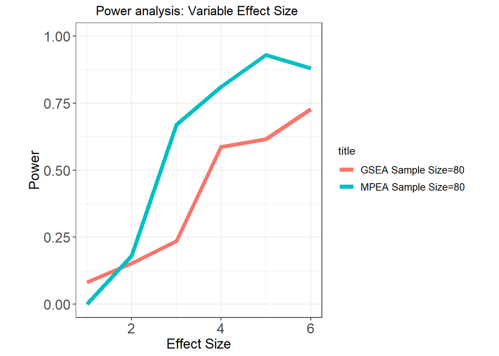

```r
p <-  ggplot(data = subset(power_analysis, Sample_size%in%c(80)), aes(x = Effectvalues, y = Power, color=title))+ geom_line(size=2)+theme_bw()+
  theme(axis.text=element_text(size=14), axis.title=element_text(size=14), legend.text=element_text(size=10), plot.title = element_text(hjust = 0.5))+xlab("Effect Size")+
  ggtitle("Power analysis: Variable Effect Size ")+ coord_fixed(ylim = c(0,1), ratio = 6/1)
p
```

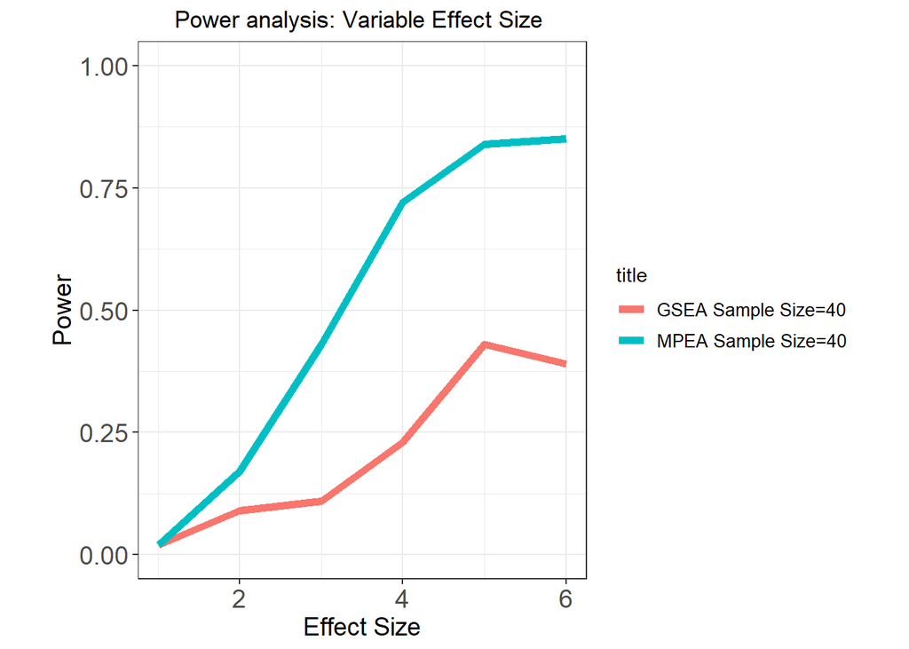

```r
p <-  ggplot(data = subset(power_analysis, Sample_size%in%c(40)), aes(x = Effectvalues, y = Power, color=title))+ geom_line(size=2)+theme_bw()+
  theme(axis.text=element_text(size=14), axis.title=element_text(size=14), legend.text=element_text(size=10), plot.title = element_text(hjust = 0.5))+xlab("Effect Size")+
  ggtitle("Power analysis: Variable Effect Size ")+ coord_fixed(ylim = c(0,1), ratio = 6/1)
p
```

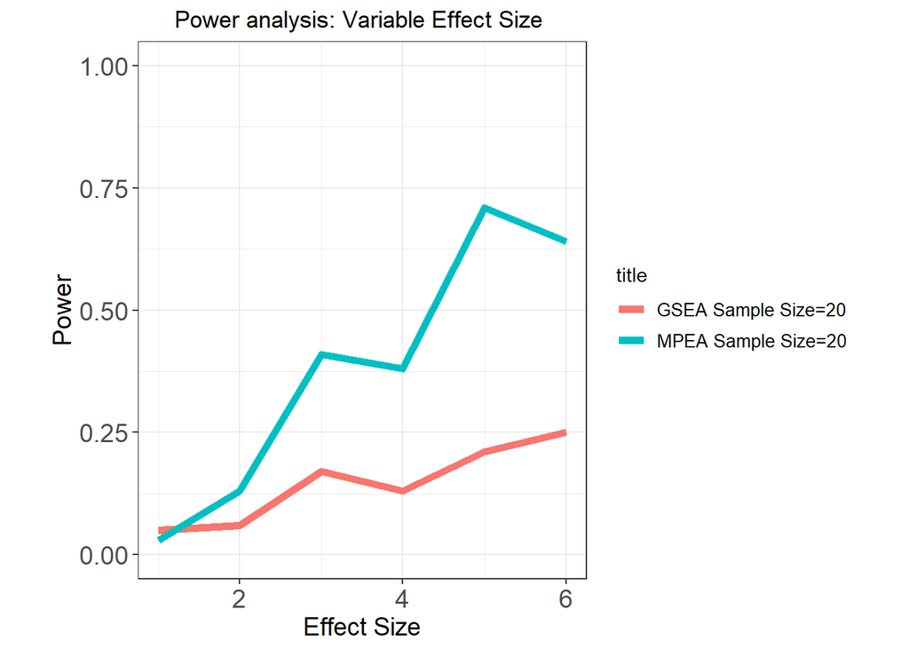

```r
p <-  ggplot(data = subset(power_analysis, Sample_size%in%c(20)), aes(x = Effectvalues, y = Power, color=title))+ geom_line(size=2)+theme_bw()+
  theme(axis.text=element_text(size=14), axis.title=element_text(size=14), legend.text=element_text(size=10), plot.title = element_text(hjust = 0.5))+xlab("Effect Size")+
  ggtitle("Power analysis: Variable Effect Size ")+ coord_fixed(ylim = c(0,1), ratio = 6/1)
p
```

# GSEA power analysis while changing Effect size inside the pathway and keeping the enrichment level constant

```r
# # rm(list=ls())
# nsamples <- seq(20,100,20)
# power_output <- readRDS("GSEA_power_similar_enrichment_variable_effect.RDS")
# power_analysis <- melt(power_output)
# power_analysis$Sample_size <- nsamples
# names(power_analysis) <- c("Effect","Power","Sample_size")
# powe
# power_analysis <- power_analysis[c("Power", "Effect","Sample_size")]
# p <-  ggplot(data = power_analysis, aes(x = Sample_size, y = Power, color=Effect))+ geom_line(size=2)+theme_bw()+
#   theme(axis.text=element_text(size=14), axis.title=element_text(size=14), legend.text=element_text(size=10), plot.title = element_text(hjust = 0.5))+xlab("Sample Size")+
#   ggtitle("Power analysis: Variable Effect Size ")
# p
```

# Power Analysis of changing the Pathway compensator window size

In this scenario, we keep every parameter as constant and only change the the Pathway compensator window size.

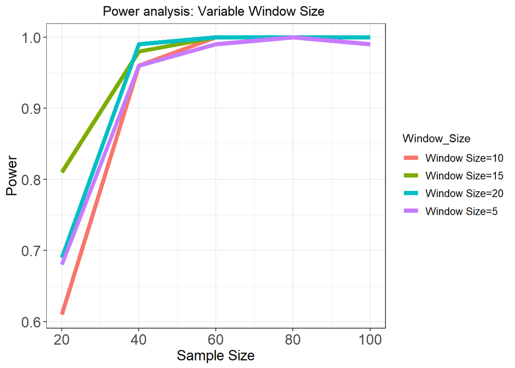

```r
rm(list=ls())
p_value_variable_window_size <- readRDS(file = "p_value_variable_window_size_mean.RDS")
SPZ= seq(5,20, by=5)
power_output <- list()
nsamples <- seq(20,100,20)
for (jj in 1:length(SPZ)){
  aux <- sapply(p_value_variable_window_size, FUN = function(x) x[[jj]]< 0.05  )
  power_output[[jj]] <- rowSums(aux)/dim(aux)[2]

}
names(power_output) <- paste( "Window Size=",SPZ, sep = "")
power_analysis <- melt(power_output)
power_analysis$Sample_size <- nsamples
names(power_analysis) <- c("Power", "Window_Size","Sample_size")
p <- ggplot(data = power_analysis, aes(x = Sample_size, y = Power, color=Window_Size))+ geom_line(size=2)+theme_bw()+
  theme(axis.text=element_text(size=14), axis.title=element_text(size=14), legend.text=element_text(size=10), plot.title = element_text(hjust = 0.5))+xlab("Sample Size")+
  ggtitle("Power analysis: Variable Window Size ")
p
```

# Power Analysis of changing the Pathway Size

In this scenario, we keep every parameter as constant and only change the the Pathway size.

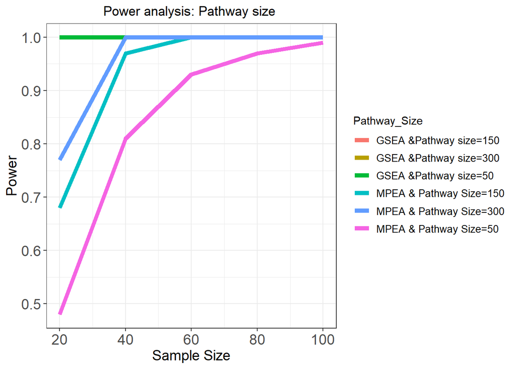

```r
rm(list=ls())
p_value_variable_pathway_size <- readRDS(file = "p_value_variable_pathway_size_mean.RDS")
# pathway_size= seq(50,300, by=50)
pathway_size= c(50,150,300)

power_output_MPEA <- list()
nsamples <- seq(20,100,20)
for (jj in 1:length(pathway_size)){
  aux <- sapply(p_value_variable_pathway_size, FUN = function(x) x[[jj]]< 0.05  )
  power_output_MPEA[[jj]] <- rowSums(aux)/dim(aux)[2]

}
names(power_output_MPEA) <- paste( "Pathway Size=",pathway_size, sep = "")
power_analysis_MPEA <- melt(power_output_MPEA)
power_analysis_MPEA$Sample_size <- nsamples
names(power_analysis_MPEA) <- c("Power", "Pathway_Size","Sample_size")
power_analysis_MPEA$Pathway_Size <- paste("MPEA &", power_analysis_MPEA$Pathway_Size)
# p <- ggplot(data = power_analysis_MPEA, aes(x = Sample_size, y = Power, color=Pathway_Size))+ geom_line(size=2)+theme_bw()+
#   theme(axis.text=element_text(size=14), axis.title=element_text(size=14), legend.text=element_text(size=10), plot.title = element_text(hjust = 0.5))+xlab("Sample Size")+
#   ggtitle("Power analysis: Variable Pathway Size ")
# p

power_output_GSEA <- readRDS("GSEA_pathway_variable.RDS")
power_analysis_GSEA <- melt(power_output_GSEA)
power_analysis_GSEA$Sample_size <- nsamples
names(power_analysis_GSEA) <- c("Pathway_Size","Power","Sample_size")
power_analysis_GSEA <- power_analysis_GSEA[c("Power", "Pathway_Size","Sample_size")]
power_analysis_GSEA$Pathway_Size <- paste("GSEA &", power_analysis_GSEA$Pathway_Size,sep = "")

power_analysis <- rbind(power_analysis_MPEA,power_analysis_GSEA)

p <- ggplot(data = power_analysis, aes(x = Sample_size, y = Power, color=Pathway_Size))+ geom_line(size=2)+theme_bw()+
  theme(axis.text=element_text(size=14), axis.title=element_text(size=14), legend.text=element_text(size=10), plot.title = element_text(hjust = 0.5))+xlab("Sample Size")+
  ggtitle("Power analysis: Pathway size ")
p
```

# GSEA power analysis while changing pathway size In our test level GSEA performs superiorly to MPEA. It appears that GSEA suffers much less from pathway size effect, which is expectable considering their pathway size normalization.

```r
# # rm(list=ls())
# nsamples <- seq(20,100,20)
# power_output <- readRDS("GSEA_pathway_variable.RDS")
# power_analysis <- melt(power_output)
# power_analysis$Sample_size <- nsamples
# names(power_analysis) <- c("Pathway_size","Power","Sample_size")
#
# p <- ggplot(data = power_analysis, aes(x = Sample_size, y = Power, color=Pathway_size))+ geom_line(size=2)+theme_bw()+
#   theme(axis.text=element_text(size=14), axis.title=element_text(size=14), legend.text=element_text(size=10), plot.title = element_text(hjust = 0.5))+xlab("Sample Size")+
#   ggtitle("Power analysis: Pathway size ")
# p
```